# Community detection

Pablo Barbera

#### Importing network data into R

In this training session we will be using a small dataset to illustrate how to identify latent communities in networks. The dataset corresponds to the Twitter ego network of POIR – each node is another Twitter account that the USC POIR account follows, and the edges indicate whether each of those accounts in turn follow each other. (See at the end of this script for the code on how I put together this network.) Edges are thus directed.

The first step is to read the list of edges and nodes in this network:

```r
edges <- read.csv("data/poir-edges.csv", stringsAsFactors=FALSE)
head(edges)
```

```
##      Source     Target
## 1 112448318  116630713
## 2 112448318  119679411
## 3 112448318  119682506
## 4 112448318  135469780
## 5 112448318 1852171094
## 6 112448318  186894716
```

```r
nodes <- read.csv("data/poir-nodes.csv", stringsAsFactors=FALSE)
head(nodes)
```

```
##           Id          Label                name
## 1  112448318         BJPolS British Jnl Pol Sci
## 2 1137637033    AJPS_Editor                AJPS
## 3  114865774    USCGouldLaw       USC Gould Law
## 4  116630713 monkeycageblog         Monkey Cage
## 5 1170012108        CESRUSC                CESR
## 6 1180479770          jaj7d        Jeff Jenkins
##                                                                                                                                                        description
## 1                                                                                            British Journal of Political Science from Cambridge University Press.
## 2                                                                         American Journal of Political Science - AJPS Co-Editors Kathy Dolan and Jennifer Lawless
## 3                                                           A top-20 law school, USC Gould offers students a world-class education and unparalleled opportunities.
## 4 Democracy is the art of running the circus from the monkey cage. -- H.L. Mencken. Political science for the public. Making sense of the circus that is politics.
## 5                                                                                          We conduct basic and applied research in economics and social sciences.
## 6                                                 Provost Professor of Public Policy, Political Science, and Law. @USC Director, @BedrosianCenter, @The_JOP editor
##   followers_count statuses_count friends_count
## 1           12658           4768           836
## 2           11211            666            97
## 3            7270           9235          2841
## 4           47278          21650           750
## 5             408            400           289
## 6             557            414           281
##                       created_at        location
## 1 Mon Feb 08 14:52:14 +0000 2010       Cambridge
## 2 Thu Jan 31 18:42:30 +0000 2013
## 3 Tue Feb 16 21:24:55 +0000 2010 Los Angeles, CA
## 4 Tue Feb 23 03:53:00 +0000 2010
## 5 Mon Feb 11 21:01:26 +0000 2013
## 6 Thu Feb 14 22:26:28 +0000 2013 Los Angeles, CA
```

For example, we learn that user with ID 112448318 follows user with ID 116630713

How do we convert these two datasets into a network object in R? There are multiple packages to work with networks, but the most popular is `igraph` because it’s very flexible and easy to do, and in my experience it’s much faster and scales well to very large networks. Other packages that you may want to explore are `sna` and `networks`.

Now, how do we create the igraph object? We can use the `graph_from_data_frame` function, which takes two arguments: `d`, the data frame with the edge list in the first two columns; and `vertices`, a data frame with node data with the node label in the first column. (Note that igraph calls the nodes `vertices`, but it’s exactly the same thing.)

```r
library(igraph)
g <- graph_from_data_frame(d=edges, vertices=nodes, directed=FALSE)
g
```

```
## IGRAPH 9ec3758 UN-- 150 4047 --
## + attr: name (v/c), Label (v/c), description (v/c),
## | followers_count (v/n), statuses_count (v/n), friends_count
## | (v/n), created_at (v/c), location (v/c)
## + edges from 9ec3758 (vertex names):
## [1] British Jnl Pol Sci--Monkey Cage
## [2] British Jnl Pol Sci--Euro Pol Sci Review
## [3] British Jnl Pol Sci--International Theory
## [4] British Jnl Pol Sci--EPSA
## [5] British Jnl Pol Sci--MPSA
## [6] British Jnl Pol Sci--Political Analysis
## + ... omitted several edges
```

What does it mean? - `U` means undirected  
- `N` means named graph  
- `150` is the number of nodes  
- `4047` is the number of edges  
- `name (v/c)` means *name* is a node attribute and it’s a character

#### Network communities

Networks often have different clusters or communities of nodes that are more densely connected to each other than to the rest of the network. Let’s cover some of the different existing methods to identify these communities.

The most straightforward way to partition a network is into **connected components**. Each component is a group of nodes that are connected to each other, but *not* to the rest of the nodes. For example, this network has only one component (every node is at least connected to one other node in the network).

```r
str(components(g))
```

```
## List of 3
##  $ membership: Named num [1:150] 1 1 1 1 1 1 1 1 1 1 ...
##   ..- attr(*, "names")= chr [1:150] "British Jnl Pol Sci" "AJPS" "USC Gould Law" "Monkey Cage" ...
##  $ csize     : num 150
##  $ no        : int 1
```

Most networks have a single **giant connected component** that includes most nodes. Most studies of networks actually focus on the giant component (e.g. the shortest path between nodes in a network with two or more component is Inf!).

```r
giant <- decompose(g, mode="strong")
giant
```

```
## [[1]]
## IGRAPH dbb1b23 UN-- 150 4047 --
## + attr: name (v/c), Label (v/c), description (v/c),
## | followers_count (v/n), statuses_count (v/n), friends_count
## | (v/n), created_at (v/c), location (v/c)
## + edges from dbb1b23 (vertex names):
## [1] British Jnl Pol Sci--Monkey Cage
## [2] British Jnl Pol Sci--Euro Pol Sci Review
## [3] British Jnl Pol Sci--International Theory
## [4] British Jnl Pol Sci--EPSA
## [5] British Jnl Pol Sci--MPSA
## [6] British Jnl Pol Sci--Political Analysis
## + ... omitted several edges
```

Components can be **weakly connected** (in undirected networks) or **strongly connected** (in directed networks, where there is an edge that ends in every single node of that component).

```r
weakly <- decompose(g, mode="weak")
weakly
```

```
## [[1]]
## IGRAPH e7ff3a3 UN-- 150 4047 --
## + attr: name (v/c), Label (v/c), description (v/c),
## | followers_count (v/n), statuses_count (v/n), friends_count
## | (v/n), created_at (v/c), location (v/c)
## + edges from e7ff3a3 (vertex names):
## [1] British Jnl Pol Sci--Monkey Cage
## [2] British Jnl Pol Sci--Euro Pol Sci Review
## [3] British Jnl Pol Sci--International Theory
## [4] British Jnl Pol Sci--EPSA
## [5] British Jnl Pol Sci--MPSA
## [6] British Jnl Pol Sci--Political Analysis
## + ... omitted several edges
```

Even within a giant component, there can be different subsets of the network that are more connected to each other than to the rest of the network. The goal of **community detection algorithms** is to identify these subsets.

There are a few different algorithms, each following a different logic.

The **walktrap** algorithm finds communities through a series of short random walks. The idea is that these random walks tend to stay within the same community. The length of these random walks is 4 edges by default, but you may want to experiment with different values (longer random walks will lead to fewer communities). The goal of this algorithm is to identify the partition that maximizes a modularity score.

```r
cluster_walktrap(g)
```

```
## IGRAPH clustering walktrap, groups: 7, mod: 0.33
## + groups:
##   $`1`
##    [1] "USC Gould Law"
##    [2] "CESR"
##    [3] "USC Dornsife"
##    [4] "USC Sociology"
##    [5] "USC History Dept. ✌️"
##    [6] "Ray Kwong"
##    [7] "USC Office of Religious & Spiritual Life"
##    [8] "Jay Maharjan"
##    [9] "USC Research"
##   + ... omitted several groups/vertices
```

```r
cluster_walktrap(g, steps=10)
```

```
## IGRAPH clustering walktrap, groups: 4, mod: 0.31
## + groups:
##   $`1`
##    [1] "Government Innovations at Harvard"
##    [2] "ACLU"
##    [3] "USA TODAY"
##    [4] "NCSL"
##    [5] "Marist Poll"
##    [6] "Simon Radford"
##    [7] "Tim Scott"
##    [8] "The Washington Post"
##    [9] "Fanny Cisneros"
##   + ... omitted several groups/vertices
```

```r
cluster_walktrap(g, steps=20)
```

```
## IGRAPH clustering walktrap, groups: 3, mod: 0.31
## + groups:
##   $`1`
##    [1] "USC Gould Law"
##    [2] "CESR"
##    [3] "USC Dornsife"
##    [4] "USC Sociology"
##    [5] "USC History Dept. ✌️"
##    [6] "Ray Kwong"
##    [7] "Sen. Barbara Boxer"
##    [8] "USC Office of Religious & Spiritual Life"
##    [9] "Jay Maharjan"
##   + ... omitted several groups/vertices
```

```r
cluster_walktrap(g, steps=30)
```

```
## IGRAPH clustering walktrap, groups: 3, mod: 0.31
## + groups:
##   $`1`
##    [1] "USC Gould Law"
##    [2] "CESR"
##    [3] "USC Dornsife"
##    [4] "USC Sociology"
##    [5] "USC History Dept. ✌️"
##    [6] "Ray Kwong"
##    [7] "Sen. Barbara Boxer"
##    [8] "USC Office of Religious & Spiritual Life"
##    [9] "Jay Maharjan"
##   + ... omitted several groups/vertices
```

Other methods are:

- The **infomap** method attempts to map the flow of information in a network, and the different clusters in which information may get remain for longer periods. Similar to walktrap, but not necessarily maximizing modularity, but rather the so-called “map equation”.
- The **edge-betweenness** method iteratively removes edges with high betweenness, with the idea that they are likely to connect different parts of the network. Here betweenness (gatekeeping potential) applies to edges, but the intuition is the same.
- The **label propagation** method labels each node with unique labels, and then updates these labels by choosing the label assigned to the majority of their neighbors, and repeat this iteratively until each node has the most common labels among its neighbors.
- The **Louvain algorithm** initially assigns each node to its own community; nodes are then sequentially assigned to the community that increases modularity (if any) so that communities are merged; this merging process continues until modularity cannot increase or only one community remains.

```r
cluster_infomap(g)
cluster_edge_betweenness(g)
cluster_label_prop(g)
cluster_louvain(g)
```

The choice of one or other algorithm may depend on substantive or practical reasons, as always. For now, let’s pick the Louvain algorithm, which identifies four clusters.

```r
comm <- cluster_louvain(g)
nodes$cluster <- membership(comm)
```

Who’s in each cluster?

```r
head(nodes$Label[nodes$cluster==1], n=10)
```

```
##  [1] "BJPolS"          "AJPS_Editor"     "monkeycageblog"
##  [4] "jaj7d"           "EPSRjournal"     "InternatlTheory"
##  [7] "SPSAnews"        "ACLU"            "europsa"
## [10] "NicholasNapolio"
```

```r
head(nodes$Label[nodes$cluster==2], n=10)
```

```
##  [1] "GovInnovations"  "SenatorBoxer"    "USATODAY"
##  [4] "NCSLorg"         "latimes"         "maristpoll"
##  [7] "SenatorTimScott" "FiveThirtyEight" "washingtonpost"
## [10] "fancis30"
```

```r
head(nodes$Label[nodes$cluster==3], n=10)
```

```
##  [1] "USCGouldLaw"     "CESRUSC"         "USCDornsife"
##  [4] "USCSociology"    "USCHistory"      "raykwong"
##  [7] "USCRELIGIOUSLIF" "4entrepreneur"   "USC_Research"
## [10] "USCMarshall"
```

```r
head(nodes$Label[nodes$cluster==4], n=10)
```

```
##  [1] "thereanders"    "SuzieMulesky"   "jasongiannaros" "JordanCarrP"
##  [5] "sradford22"     "curiouskyuri"   "adambbadawy"    "christiangrose"
##  [9] "taylordalton"   "_abuelbanat"
```

An even better way to understand the content of each cluster is to combine what we’ve learnt about text analysis so far. Let’s see what that reveals:

```r
library(quanteda)
# most frequent features
for (i in 1:4){
  message("Cluster ", i)
  dfm <- dfm(nodes$description[nodes$cluster==i],
             remove_punct=TRUE, remove=stopwords("english"))
  print(topfeatures(dfm, n=25))
}
```

```
## Cluster 1
```

```
##     political       science      politics       journal      research
##            26            22            12            10             7
##   association      american     professor        policy international
##             7             5             5             5             5
##         study     assistant    university           law     published
##             5             5             4             4             4
##     cambridge         press        public      european            us
##             3             3             3             3             3
##       studies        circus   endorsement          aclu  organization
##             3             2             2             2             2
```

```
## Cluster 2
```

```
##      https       t.co       news        u.s government    senator
##          9          9          8          4          3          3
##       poll     public    opinion   breaking     create california
##          3          3          3          3          2          2
##    stories   official    twitter   national      state      staff
##          2          2          2          2          2          2
##      since        l.a      world    founded        new     across
##          2          2          2          2          2          2
##   analysis
##          2
```

```
## Cluster 3
```

```
##           usc      official        school       twitter      research
##            24            11            10             9             8
##       account    university    california    department      southern
##             8             8             8             8             7
##            us        center        follow        public          news
##             7             7             6             6             6
##       studies     education        social         media          t.co
##             5             4             4             4             4
##          east         study environmental        offers       leading
##             4             4             4             3             3
```

```
## Cluster 4
```

```
##        phd  political   @uscpoir    science  candidate   politics
##         15         15         14         12         11         11
##        usc     social  assistant  professor    student       ph.d
##          9          8          7          7          7          6
##       @usc     policy   southern california      media         ir
##          5          5          5          5          5          4
## university       data      human     rights     alumna     public
##          4          3          3          3          3          3
##      https
##          3
```

```r
# most distinctive features
poir <- dfm(corpus(nodes[,c("description", "cluster")], text_field="description"))
for (i in 1:4){
    print(
      head(textstat_keyness(poir, target=docvars(poir)$cluster==i,
                      measure="lr"), n=20)
    )
}
```

```
##          feature        G2            p n_target n_reference
## 1      political 28.174742 1.108416e-07       26          18
## 2        science 25.432244 4.581955e-07       22          14
## 3        journal 20.644569 5.529380e-06       10           1
## 4    association 16.236102 5.591829e-05        7           0
## 5           that 10.551115 1.161180e-03        5           0
## 6       politics  8.077158 4.482670e-03       12          13
## 7      published  7.772765 5.303981e-03        4           0
## 8       american  7.554372 5.986464e-03        5           1
## 9              (  7.052736 7.914429e-03       10           9
## 10             )  7.052736 7.914429e-03       10           9
## 11     cambridge  5.070727 2.433317e-02        3           0
## 12      european  5.070727 2.433317e-02        3           0
## 13             ,  4.653103 3.099746e-02       47         113
## 14            is  3.402963 6.507942e-02        8          10
```

[output cut: 69 more lines]

```r
# location
poir <- dfm(corpus(nodes[,c("location", "cluster")], text_field="location"))
for (i in 1:4){
    print(
      head(textstat_keyness(poir, target=docvars(poir)$cluster==i,
                      measure="lr"), n=20)
    )
}
```

```
##       feature        G2          p n_target n_reference
## 1         new 3.7507487 0.05278386        4           3
## 2          uk 3.1060277 0.07800299        2           0
## 3  university 3.1060277 0.07800299        2           0
## 4          ny 1.8345401 0.17559223        3           3
## 5        york 1.8345401 0.17559223        3           3
## 6      states 1.5888608 0.20748897        2           1
## 7   cambridge 0.5265798 0.46804835        1           0
## 8     atlanta 0.5265798 0.46804835        1           0
## 9          ga 0.5265798 0.46804835        1           0
## 10        all 0.5265798 0.46804835        1           0
## 11         50 0.5265798 0.46804835        1           0
## 12     europe 0.5265798 0.46804835        1           0
## 13    chicago 0.5265798 0.46804835        1           0
## 14         il 0.5265798 0.46804835        1           0
```

[output cut: 69 more lines]

The final way in which we can think about network communities is in terms of hierarchy or structure. We’ll discuss one of these methods.

**K-core decomposition** allows us to identify the core and the periphery of the network. A k-core is a maximal subnet of a network such that all nodes have at least degree K.

```r
str(coreness(g))
```

```
##  Named num [1:150] 35 35 39 36 39 35 21 19 6 39 ...
##  - attr(*, "names")= chr [1:150] "British Jnl Pol Sci" "AJPS" "USC Gould Law" "Monkey Cage" ...
```

```r
head(which(coreness(g)==39), n=10) # what is the core of the network?
```

```
##                            USC Gould Law
##                                        3
##                                     CESR
##                                        5
##                             USC Dornsife
##                                       10
##                            USC Sociology
##                                       11
##                           Therese Anders
##                                       12
##                      USC History Dept. ✌️
##                                       16
## USC Office of Religious & Spiritual Life
##                                       19
##                             Nico Napolio
##                                       21
##                             USC Research
##                                       23
##                            Suzie Mulesky
##                                       24
```

```r
head(which(coreness(g)==1), n=10) # what is the periphery of the network?
```

```
## named integer(0)
```

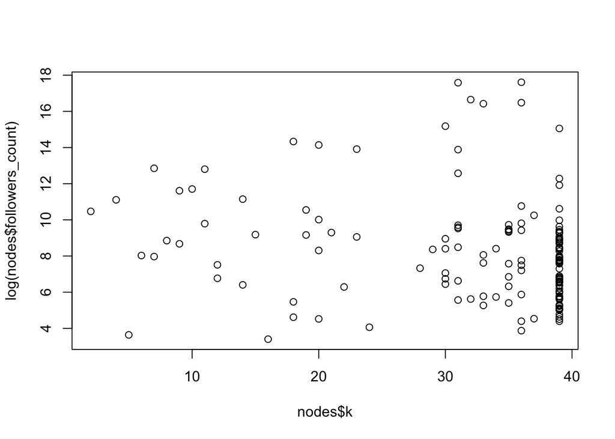

```r
# looking at what predicts being in the core
nodes$k <- coreness(g)
# number of followers?
plot(nodes$k, log(nodes$followers_count))
```

```r
cor(nodes$k, log(nodes$followers_count))
```

```
## [1] -0.1992886
```

```r
# text?
poir <- dfm(corpus(nodes[,c("description", "k")], text_field="description"))
head(textstat_keyness(poir, target=docvars(poir)$k>=35,
                      measure="lr"), n=20)
```

```
##         feature       G2          p n_target n_reference
## 1             & 8.944482 0.00278309       45           9
## 2             , 6.514822 0.01069790      119          41
## 3             • 5.217250 0.02236389       10           0
## 4             | 5.118214 0.02367597       34           8
## 5             i 4.468167 0.03453201        9           0
## 6      @uscpoir 4.150951 0.04161116       14           2
## 7      research 2.951751 0.08578457       15           3
## 8           phd 2.470379 0.11600992       14           3
## 9       studies 1.984493 0.15891783        9           1
## 10    political 1.981601 0.15922188       33          11
## 11    education 1.653446 0.19849052        5           0
## 12    relations 1.653446 0.19849052        5           0
## 13       policy 1.532419 0.21574971       11           2
## 14       center 1.472208 0.22499760        8           1
## 15          usc 1.344407 0.24625829       26           9
## 16    candidate 1.122599 0.28935961       10           2
## 17 institutions 1.034458 0.30911386        4           0
## 18          you 1.034458 0.30911386        4           0
## 19           ir 1.034458 0.30911386        4           0
## 20       change 1.034458 0.30911386        4           0
```

```r
head(textstat_keyness(poir, target=docvars(poir)$k<35,
                      measure="lr"), n=20)
```

```
##       feature       G2           p n_target n_reference
## 1          by 9.471581 0.002086794       11           3
## 2           / 6.918120 0.008532661       32          31
## 3         u.s 6.693546 0.009676253        5           0
## 4        t.co 4.096447 0.042973433       10           7
## 5        from 3.970376 0.046307441        9           6
## 6         the 3.136235 0.076570396       49          66
## 7       https 3.081854 0.079170252        9           7
## 8    european 3.008302 0.082839017        3           0
## 9     senator 3.008302 0.082839017        3           0
## 10      mayor 3.008302 0.082839017        3           0
## 11       poll 3.008302 0.082839017        3           0
## 12    journal 2.703878 0.100104476        7           4
## 13 government 2.571586 0.108798620        4           1
## 14       more 2.571586 0.108798620        4           1
## 15       most 2.571586 0.108798620        4           1
## 16         to 1.614701 0.203832224       15          18
## 17     create 1.347732 0.245675068        2           0
## 18       aclu 1.347732 0.245675068        2           0
## 19      space 1.347732 0.245675068        2           0
## 20       also 1.347732 0.245675068        2           0
```

If you want to learn more about this technique, see our [paper in PLOS ONE](http://journals.plos.org/plosone/article?id=10.1371/journal.pone.0143611) where we use it to study large-scale Twitter networks in the context of protest events.

In case you’re curious, here’s the code I used to collect the data:

```r
library(tweetscores)
options(stringsAsFactors=F)
oauth_folder = "~/Dropbox/credentials/twitter/"

accounts <- getFriends("uscpoir", oauth=oauth_folder)

# creating folders (if they do not exists)
try(dir.create("friends"))

# first check if there's any list of friends already downloaded to 'outfolder'
accounts.done <- gsub(".rdata", "", list.files("friends"))
accounts.left <- accounts[accounts %in% accounts.done == FALSE]
accounts.left <- accounts.left[!is.na(accounts.left)]

# loop over the rest of accounts, downloading friend lists from API
while (length(accounts.left) > 0){

    # sample randomly one account to get friends
    new.user <- sample(accounts.left, 1)
    #new.user <- accounts.left[1]
    cat(new.user, "---", length(accounts.left), " accounts left!\n")

    # download followers (with some exception handling...)
    error <- tryCatch(friends <- getFriends(user_id=new.user,
        oauth=oauth_folder, sleep=0.5, verbose=FALSE), error=function(e) e)
    if (inherits(error, 'error')) {
        cat("Error! On to the next one...")
        accounts.left <- accounts.left[-which(accounts.left %in% new.user)]
        next
    }

    # save to file and remove from lists of "accounts.left"
    file.name <- paste0("friends/", new.user, ".rdata")
    save(friends, file=file.name)
    accounts.left <- accounts.left[-which(accounts.left %in% new.user)]

}

# keeping only those for which we have the name
accounts <- gsub(".rdata", "", list.files("friends"))

# reading and creating network
edges <- list()
for (i in 1:length(accounts)){
    file.name <- paste0("friends/", accounts[i], ".rdata")
    load(file.name)
    if (length(friends)==0){ next }
    chosen <- accounts[accounts %in% friends]
    if (length(chosen)==0){ next }
    edges[[i]] <- data.frame(
        source = accounts[i], target = chosen)
}

edges <- do.call(rbind, edges)
nodes <- data.frame(id_str=unique(c(edges$source, edges$target)))

# adding user data
users <- getUsersBatch(ids=nodes$id_str, oauth=oauth_folder)
nodes <- merge(nodes, users)

library(igraph)
g <- graph_from_data_frame(d=edges, vertices=nodes, directed=TRUE)
g

names(nodes)[1:2] <- c("Id", "Label")
names(edges)[1:2] <- c("Source", "Target")
write.csv(nodes, file="data/poir-nodes.csv", row.names=FALSE)
write.csv(edges, file="data/poir-edges.csv", row.names=FALSE)
```